# Relationship_fitness_genomic_offset

Thomas Francisco

2024-09-18

# 1 Introduction

To evaluate the relevance of the genomic offset in providing insight into potential maladaptation to climate across studied *T. baccata* populations, we investigated the potential relationship between fitness proxies and genomic offset predictions using an independent dataset of populations not used to build the gene-climate models. Genomic offset values for each population were calculated as the Euclidean distance between the predicted optimal genomic compositions under the population’s reference climate and the clonal bank’s climate from the planting to the measurement dates. We used two methods to calculate the genomic offset:  
- RDA method with 7 sets of SNPs  
- Gradient forest with 7 sets of SNPs

For the phenotypic data, we aimed to retain the most fitness-related traits. We selected four traits: - Growth: Shoot volume  
- Growth phenology: Spring elongation  
- Reproductive phenology: proportion of male open strobili  
- Ecophysiological: leaf thickness

To search for an association between the phenotypic data and the genomic offset predictions, we used several analyses: - Pearson correlation  
- linear model: inferential and Bayesian approaches  
- non linear model: inferential and Bayesian approaches

# 2 Data

```r
meta_data <- read.csv("C:/Users/tfrancisco/Documents/Thesis/Data/Species/Taxus_baccata/Populations/Populations_common_garden.csv",h=T,sep=";",dec=",")
```

## 2.1 BLUPs data

First, we loaded the phenotypic BLUP data at the population level. Only the BLUPs at the population level were kept.  
For growth, growth, and reproductive phenology:

```r
#list_traits <-c("growth","growth_pheno","repro_pheno","leafthickness","LMA","StomDens","D13C")
list_traits <-c("growth","growth_pheno","repro_pheno")#"growth_newformulationfinal"

#selection of the right coeff
list_x <- c(2,2,2)#,3
list_y <- c(27,27,19)#,28

for(i in 1:length(list_traits)){

  trait <- list_traits[i]
  X <- list_x[i]
  Y <- list_y[i]

  data <- read.csv(paste0("C:/Users/tfrancisco/Documents/Thesis/Results/species/taxus/phenotypic_data/Blups_mean/Blups_",trait,"_period.csv"),h=T,sep=";",dec=",")

  data_pop <- data[X:Y,] #keep only the Blup at the population level
  colnames(data_pop) <- c("Population","Blups")
  data_pop$Population <- str_remove(data_pop$Population, "Population\\.")

  assign(paste0("df_",trait),data_pop)
}
```

For leaf thickness:

```r
list_traits <-c("leafthickness")#"growth_bis","StomDens","LMA"

#selection of the right coeff
list_x <- c(2,2,2,2)
list_y <- c(27,27,27,27)

for(i in 1:length(list_traits)){

  trait <- list_traits[i]
  X <- list_x[i]
  Y <- list_y[i]

  data <- read.csv(paste0("C:/Users/tfrancisco/Documents/Thesis/Results/species/taxus/phenotypic_data/Blups_mean/Blups_",trait,"final_period.csv"),h=T,sep=";",dec=",")

  data_pop <- data[X:Y,] #keep only the Blup at the population level
  colnames(data_pop) <- c("Population","Blups")
  data_pop$Population <- str_remove(data_pop$Population, "Population\\.")

  assign(paste0("df_",trait),data_pop)
}
```

We removed populations that had too few individuals measured.

```r
#Shootvol
#We remove the ACEBDO, LASENIA pop
df_growth_final <- df_growth %>%
  filter(!(Population %in% c("ACEBEDO", "LASENIA")))

#springelong
#We remove the ACEBEDO, ALCOY, LASENIA and QUESADA pop

df_growth_pheno_final <- df_growth_pheno %>%
  filter(!(Population %in% c("ACEBEDO", "ALCOY", "LASENIA","QUESADA")))

#totalstrobopen
#We remove the BOCA, JERTE, LASENIA, PUBLA and RASQUERA
df_repro_pheno_final <- df_repro_pheno %>%
  filter(!(Population %in% c("BOCAHUERGANO", "JERTE", "LASENIA","   PUEBLALILLO","RASQUERA")))

#leaves traits
#remove ACEBEDO, ALCOY, LASENIA and QUESADA
##leafthickness
df_leafthickness_final <- df_leafthickness %>%
  filter(!(Population %in% c("ACEBEDO", "ALCOY", "LASENIA","    QUESADA")))

#Shootvol new
#We remove the ACEBDO, LASENIA pop
#df_growth_newformulation_final <- df_growth_newformulationfinal %>%
  #filter(!(Population %in% c("ACEBEDO", "LASENIA")))
```

## 2.2 Correlation phenotypic traits

We investigated the correlation of the phenotypic traits of populations:

```r
colnames(df_growth_final) <- c("Population","Growth")
colnames(df_growth_pheno_final) <- c("Population","Growth_pheno")
colnames(df_repro_pheno_final) <- c("Population","Repro_pheno")
colnames(df_leafthickness_final) <- c("Population","Leafthickness")

merged_df <- df_growth_final %>%
  full_join(df_growth_pheno_final, by = "Population") %>%
  full_join(df_repro_pheno_final, by = "Population") %>%
  full_join(df_leafthickness_final, by = "Population")
```

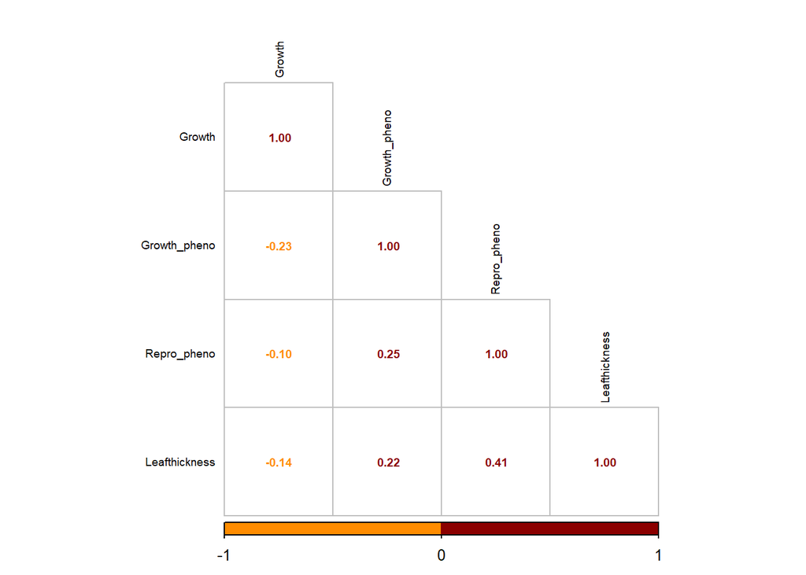

```r
correlation_phenotypic_traits <- cor(merged_df[,-1], use="pairwise.complete.obs")

corrplot(correlation_phenotypic_traits, method = "number", addrect = 2, col = c("darkorange","darkred"), type = "lower", tl.col = "black", tl.cex = 0.6, number.cex = 0.6)
```

```r
pdf("C:/Users/tfrancisco/Documents/Thesis/Results/species/taxus/phenotypic_data/figures/Correlation/correlation_phenotypic_traits_BLUPs.pdf");corrplot(correlation_phenotypic_traits, method = "number", addrect = 2, col = c("darkorange","darkred"), type = "lower", tl.col = "black", tl.cex = 0.6, number.cex = 0.6);dev.off()
```

We can see that the phenotypic traits do not appear to be closely related, as the correlations are quite low. Could this indicate that they are responding to different selective pressures? Or is there a trade-off? Does that also mean that they provide complementary information about fitness?

## 2.3 Composite fitness index

We also attempted to combine these various traits into a single index, as fitness is multi-faceted, particularly for long-lived organisms such as trees. The idea is to organise populations based on their trait values and what appears to be adaptive in the common garden. For instance, high growth is advantageous, so the population with the highest growth rate out of the 26 populations will have the highest value. These values will be scaled to give equal weight to each trait, since we do not have the same number of populations for each trait (using rank values would give more weight to traits with more populations). To standardise the values, we are applying the following formula: Standardized trait= (trait - min_value_trait)/(max_value_trait - min_value_trait)

```r
list_traits <- c("growth","growth_pheno","repro_pheno","leafthickness")#"growth_newformulation",

for(x in 1: length(list_traits)){

  trait <- list_traits[x]
  df <- get(paste0("df_", trait,"_final"))

  df_standardized <- df %>%
  mutate(
    trait_scaled = (df[,2] - min(df[,2])) / (max(df[,2]) - min(df[,2])))

  colnames(df_standardized) <- c("Population","Blups",paste0(trait,"_standardized"))

  assign(paste0("df_standardized_", trait), df_standardized)
}
```

```r
final_tot_standardized_traits <- reduce(list(df_standardized_growth[,-2], df_standardized_growth_pheno[,-2], df_standardized_repro_pheno[,-2], df_standardized_leafthickness[,-2]), full_join, by = "Population")#df_standardized_growth_newformulation
```

```r
Trait_calculation <- final_tot_standardized_traits %>%
  rowwise() %>%
  dplyr::mutate(
    # Calculate the sum of standardized traits, ignoring NAs
    valid_traits_sum = sum(c_across(ends_with("_standardized")), na.rm = TRUE),

    # Count non-NA standardized traits
    valid_traits_count = sum(!is.na(c_across(ends_with("_standardized")))),

    # Calculate the trait index only if there is at least one valid trait
    trait_index = if_else(valid_traits_count > 0,
                          valid_traits_sum / valid_traits_count,
                          NA_real_)
  ) %>%
  dplyr::select(-valid_traits_sum, -valid_traits_count) %>%  # Optionally remove helper columns
  ungroup()

# View the combined data frame with trait index
print(Trait_calculation)
```

```
## # A tibble: 26 × 6
##    Population  growth_standardized growth_pheno_standar…¹ repro_pheno_standard…²
##    <chr>                     <dbl>                  <dbl>                  <dbl>
##  1 AGRES                     0                      0.767                 0.276
##  2 ALCOY                     0.264                 NA                    NA
##  3 ARAGUES                   0.206                  0.269                 0.297
##  4 ASPONTES                  0.186                  0.438                NA
##  5 BARRACO                   0.213                  0.474                 1
##  6 BEGONTE                   0.293                  0.554                NA
##  7 BOCAHUERGA…               0.279                  0.789                NA
##  8 CANENCIA                  0.588                  0.755                 0.441
##  9 CERVANTES                 0.318                  0.755                NA
## 10 FANLO                     0.591                  0.576                 0.0433
## # ℹ 16 more rows
## # ℹ abbreviated names: ¹growth_pheno_standardized, ²repro_pheno_standardized
## # ℹ 2 more variables: leafthickness_standardized <dbl>, trait_index <dbl>
```

```r
df_composite_fitness_final <- data.frame(Population=Trait_calculation[,1],Fitness_index=Trait_calculation$trait_index)
```

## 2.4 GO predictions

We loaded the genomic offset predictions for the 2 genomic offset methods:

```r
#RDA standard GO
list_RDA_standard <- c("all","random","random_same_AF","LC","CG","random_AF_V2","all_outliers")
list_period <- c("CG2012","CG2021")
for(i in 1: length(list_period)){

    period <- list_period[i]

for(x in 1:length(list_RDA_standard)){
  name <- list_RDA_standard[x]


  load(paste0("C:/Users/tfrancisco/Documents/Thesis/Results/species/taxus/Genomic_offset/Validation/GO/standard_GO/RDA/data/CG_period/GO_RDA_",name,"_",period,"_Taxus.Rdata"))
  }
}

#GF GO
list_GF_standard <- c("all","random","random_same_AF","LC","CG","random_AF_V2","all_outliers")
list_period <- c("2012","2021")
for(i in 1: length(list_period)){

   period <- list_period[i]

for(x in 1:length(list_GF_standard)){

  name <- list_GF_standard[x]


  load(paste0("C:/Users/tfrancisco/Documents/Thesis/Results/species/taxus/Genomic_offset/Validation/GO/Standard_GO/GF/data/CG_period/GO_standard_GF_",name,"_",period,".Rdata"))
}
}
```

We can investigate the correlation between the predictions across methods and models:

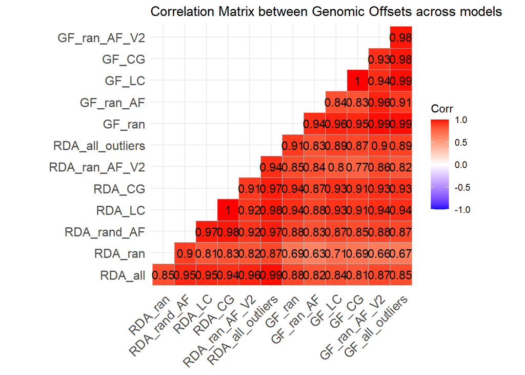

```r
df_GO <- data.frame(RDA_all=GO_RDA_all_CG2012_Taxus$GO_all_CG2012,RDA_ran=GO_RDA_random_CG2012_Taxus$GO_random_CG2012,RDA_rand_AF=GO_RDA_random_same_AF_CG2012_Taxus$GO_random_same_AF_CG2012,RDA_LC=GO_RDA_LC_CG2012_Taxus$GO_LC_CG2012,RDA_CG=GO_RDA_CG_CG2012_Taxus$GO_CG_CG2012,RDA_ran_AF_V2=GO_RDA_random_AF_V2_CG2012_Taxus$GO_random_AF_V2_CG2012,RDA_all_outliers=GO_RDA_all_outliers_CG2012_Taxus$GO_all_outliers_CG2012,GF_ran=GO_standard_GF_random_2012$genomic_offset_GF_random,GF_ran_AF=GO_standard_GF_random_same_AF_2012$genomic_offset_GF_random_same_AF,GF_LC=GO_standard_GF_LC_2012$genomic_offset_GF_LC,GF_CG=GO_standard_GF_CG_2012$genomic_offset_GF_CG,GF_ran_AF_V2=GO_standard_GF_random_AF_V2_2012$genomic_offset_GF_random_AF_V2,GF_all_outliers=GO_standard_GF_all_outliers_2012$genomic_offset_GF_all_outliers)

df <- cor(df_GO)
ggcorrplot(df, hc.order = F, type = "lower", lab = TRUE, title = "Correlation Matrix between Genomic Offsets across models")
```

# 3 Relationship fitness ~ genomic offset

## 3.1 Pearson correlations

```r
# List of RDA genomic offsets for 2012 and 2021
list_GO_2012_RDA <- c("GO_RDA_all_CG2012_Taxus","GO_RDA_random_CG2012_Taxus", "GO_RDA_random_same_AF_CG2012_Taxus",
                      "GO_RDA_LC_CG2012_Taxus","GO_RDA_random_AF_V2_CG2012_Taxus","GO_RDA_all_outliers_CG2012_Taxus")
list_GO_2021_RDA <- c("GO_RDA_all_CG2021_Taxus","GO_RDA_random_CG2021_Taxus", "GO_RDA_random_same_AF_CG2021_Taxus",
                      "GO_RDA_LC_CG2021_Taxus","GO_RDA_random_AF_V2_CG2021_Taxus","GO_RDA_all_outliers_CG2021_Taxus")

# List of Gradient Forest genomic offsets for 2012 and 2021
list_GO_2012_GF <- c("GO_standard_GF_all_2012","GO_standard_GF_random_2012", "GO_standard_GF_random_same_AF_2012",
                     "GO_standard_GF_LC_2012","GO_standard_GF_random_AF_V2_2012","GO_standard_GF_all_outliers_2012")
list_GO_2021_GF <- c("GO_standard_GF_all_2021","GO_standard_GF_random_2021", "GO_standard_GF_random_same_AF_2021",
                     "GO_standard_GF_LC_2021","GO_standard_GF_random_AF_V2_2021","GO_standard_GF_all_outliers_2021")

# Combine lists into one for easier processing
list_GO_2012 <- c(list_GO_2012_RDA, list_GO_2012_GF)
list_GO_2021 <- c(list_GO_2021_RDA, list_GO_2021_GF)

# Corresponding methods and models
list_method <- c(rep("RDA", 6), rep("GF", 6))  # 4 RDA models and 4 GF models

list_model <- c("all","random", "random_same_AF", "LC", "all","random", "random_same_AF", "LC")
list_model <- c("all","random", "random_same_AF", "outlier","random_same_AF_V2","all_outliers", "all","random", "random_same_AF", "outlier","random_same_AF_V2","all_outliers")

# Traits considered
#list_traits <- c("growth","growth_pheno","repro_pheno","leafthickness","LMA","StomDens","D13C")
list_traits <- c("growth","growth_pheno","repro_pheno","leafthickness","composite_fitness")

# Create an empty dataframe to store correlations
correlation_df <- data.frame(
  Method = character(),
  Model = character(),
  Trait = character(),
  Correlation = numeric(),
  P_value = numeric(),
  stringsAsFactors = FALSE
)

# Loop over each Genomic Offset for both RDA and GF models
for(i in 1:12) {  # Now we have 8 models (4 RDA + 4 GF)
  GO_pred_2012 <- get(list_GO_2012[i])
  GO_pred_2021 <- get(list_GO_2021[i])
  method <- list_method[i]
  model <- list_model[i]

  # Loop over each trait
  for(x in 1:length(list_traits)) {
    trait <- list_traits[x]

    # Use CG2021 data for Height, and CG2012 for other traits
    if (trait == "Leafthickness" || trait=="Composite_fitness") {
      df_trait <- get(paste0("df_", trait,"_final"))

      # Merge data frames based on population for CG2021
      merged_df <- merge(df_trait, GO_pred_2021, by = "Population", suffixes = c(".trait", ".GO"))
    } else {
      df_trait <- get(paste0("df_", trait,"_final"))

      # Merge data frames based on population for CG2012
      merged_df <- merge(df_trait, GO_pred_2012, by = "Population", suffixes = c(".trait", ".GO"))
    }

    # Calculate the correlation
    correlation <- cor(merged_df[, 2], merged_df[, 3])

  pval <- cor.test(merged_df[, 2],merged_df[, 3])
 P_value <- pval$p.value

    # Store the correlation in the dataframe
    correlation_df <- rbind(correlation_df, data.frame(Method = method, Model = model, Trait = trait, Correlation = correlation, P_value= P_value))
  }
}
# Print the correlation data frame
#print(correlation_df)
```

Corrplot phenotypic traits, genomic offset

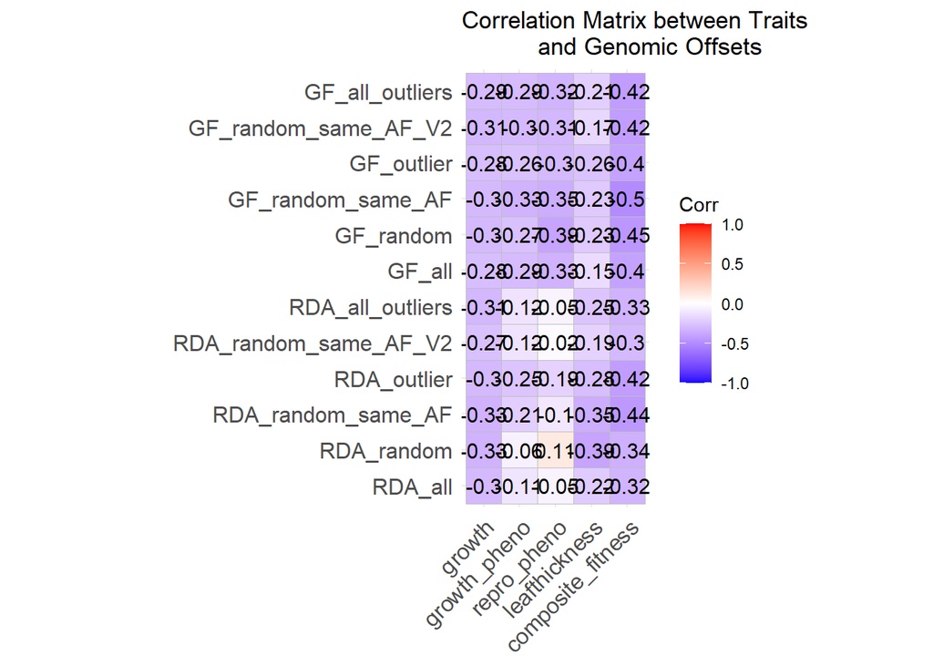

```r
# Reshape the data for corrplot if necessary
cor_matrix <- reshape(correlation_df[,-5],
                      timevar = "Trait",
                      idvar = c("Method", "Model"),
                      direction = "wide")

# Set rownames based on a combination of 'Method' and 'Model'
rownames(cor_matrix) <- paste(cor_matrix$Method, cor_matrix$Model, sep = "_")

# Remove the 'Method' and 'Model' columns since they are now in the rownames
cor_matrix <- cor_matrix[ , !(names(cor_matrix) %in% c("Method", "Model"))]

colnames(cor_matrix) <- list_traits

# create a correlation plot
cor_matrix_fitness_index <- t(cor_matrix)#to have the traits on the abscissa
ggcorrplot(cor_matrix_fitness_index, hc.order = F, type = "full", lab = TRUE, title = "Correlation Matrix between Traits
           and Genomic Offsets")
```

We want to plot the correlation results in a format similar to Camus et al 2024.

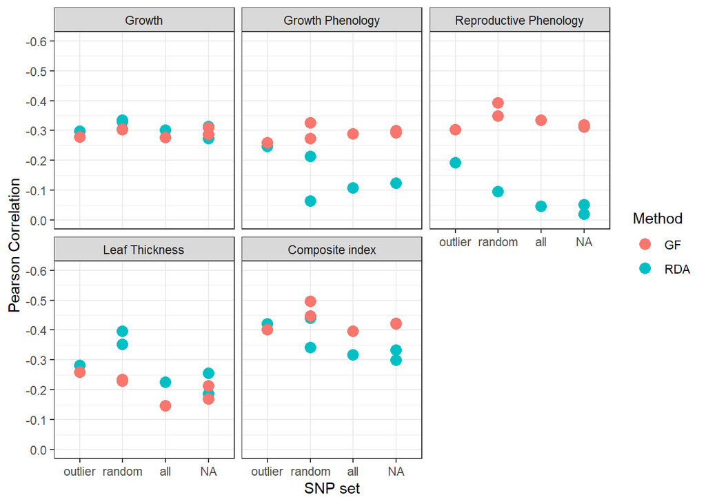

```r
# Reshape the correlation matrix for ggplot
cor_long <- melt(cor_matrix_fitness_index, varnames = c("Trait", "Method_Model"), value.name = "Correlation")

#we remove the random correlation
cor_long_reduce <- cor_long[-c(6:10,26:30),]

cor_long_reduce <- cor_long
#change the name of the random same AF correlation to simply random
cor_long_reduce$Method_Model[cor_long_reduce$Method_Model == "RDA_random_same_AF"] <- "RDA_random"
cor_long_reduce$Method_Model[cor_long_reduce$Method_Model == "GF_random_same_AF"] <- "GF_random"

# Capitalize the first letter of each trait name
cor_long_reduce$Trait <- str_to_title(cor_long_reduce$Trait)

# Separate 'Method_Model' back into 'Method' and 'Model' for better grouping
#cor_long_reduce <- cor_long_reduce %>%
 # tidyr::separate(Method_Model, into = c("Method", "Model"), sep = "_")

cor_long_reduce <- cor_long_reduce %>%
  tidyr::separate(Method_Model, into = c("Method", "Model"), sep = "_",extra="merge")

cor_long_reduce$Trait[cor_long_reduce$Trait == "Growth_pheno"] <- "Growth Phenology"
cor_long_reduce$Trait[cor_long_reduce$Trait == "Repro_pheno"] <- "Reproductive Phenology"
cor_long_reduce$Trait[cor_long_reduce$Trait == "Leafthickness"] <- "Leaf Thickness"
cor_long_reduce$Trait[cor_long_reduce$Trait == "Composite_fitness"] <- "Composite index"


#Change the order of the model and pheno in the plots
order_model <- c("outlier", "random", "all")
cor_long_reduce$Model <- factor(cor_long_reduce$Model, levels = order_model)

order_pheno <- c("Growth", "Growth Phenology", "Reproductive Phenology","Leaf Thickness","Composite index")
cor_long_reduce$Trait <- factor(cor_long_reduce$Trait, levels = order_pheno)

# Plot using ggplot2
plot <- ggplot(cor_long_reduce, aes(x = Model, y = Correlation, color = Method, group = Method)) +
  geom_point(size=3.5) +
  facet_wrap(~ Trait, scales = "fixed", nrow = 2) +
  scale_y_reverse(
    breaks = seq(0, -0.6, by = -0.1), # Custom y-axis breaks
    limits = c(0, -0.6)               # Ensure consistent limits across facets
  ) +
  labs(
    x = "SNP set",
    y = "Pearson Correlation"
  ) +
  theme_minimal() +
  theme(
    axis.text.x = element_text(angle = 45, hjust = 1),
    legend.position = "bottom"
  ) +
  theme_bw(base_size = 11)

plot
```

```r
#pdf("C:/Users/tfrancisco/Documents/Thesis/Results/species/taxus/Genomic_offset/Final_figures/Validation/Graph_nice_correlation_GO_fitness_v2.pdf");print(plot);dev.off()
```

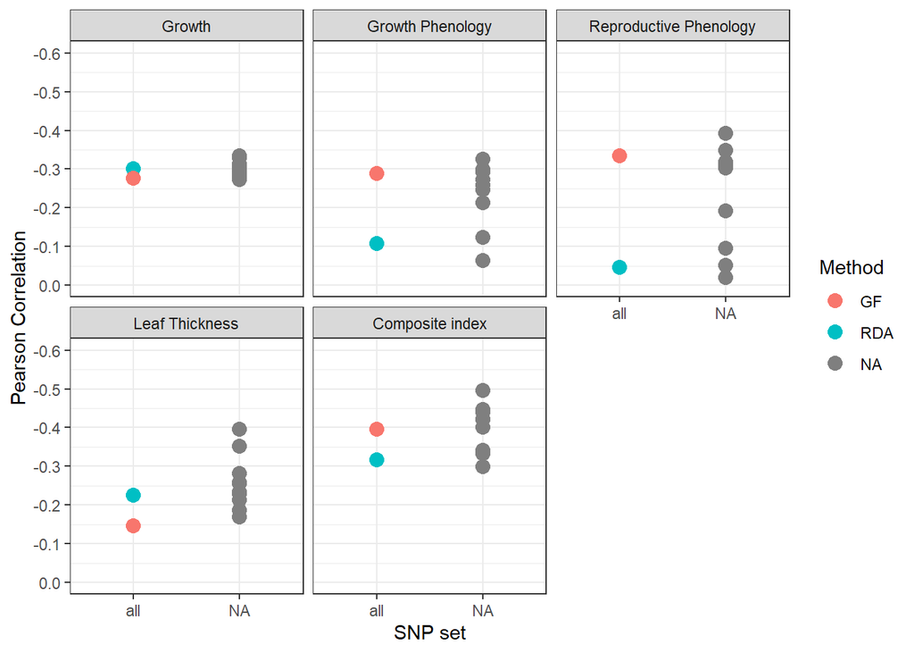

```r
# Reshape the correlation matrix for ggplot
cor_long <- melt(cor_matrix_fitness_index, varnames = c("Trait", "Method_Model"), value.name = "Correlation")

#we remove the random correlation
#cor_long_reduce <- cor_long[-c(6:10,26:30),]

cor_long_reduce <- cor_long
#change the name of the random same AF correlation to simply random
cor_long_reduce$Method_Model[cor_long_reduce$Method_Model == "RDA_random_same_AF"] <- "RDA_AF"
cor_long_reduce$Method_Model[cor_long_reduce$Method_Model == "GF_random_same_AF"] <- "GF_AF"
cor_long_reduce$Method_Model[cor_long_reduce$Method_Model == "RDA_random_same_AF_V2"] <- "RDA_AF2"
cor_long_reduce$Method_Model[cor_long_reduce$Method_Model == "GF_random_same_AF_V2"] <- "GF_AF2"
cor_long_reduce$Method_Model[cor_long_reduce$Method_Model == "RDA_outlier"] <- "RDA_out"
cor_long_reduce$Method_Model[cor_long_reduce$Method_Model == "GF_outlier"] <- "GF_out"
cor_long_reduce$Method_Model[cor_long_reduce$Method_Model == "RDA_random"] <- "RDA_r"
cor_long_reduce$Method_Model[cor_long_reduce$Method_Model == "GF_random"] <- "GF_r"
cor_long_reduce$Method_Model[cor_long_reduce$Method_Model == "RDA_all_outliers"] <- "RDA_alout"
cor_long_reduce$Method_Model[cor_long_reduce$Method_Model == "GF_all_outliers"] <- "GF_alout"

cor_long_reduce <- cor_long_reduce %>%
  mutate(Method_Model = recode(Method_Model,
    "RDA_random_same_AF" = "RDA_AF",
    "GF_random_same_AF" = "GF_AF",
    "RDA_random_same_AF_V2" = "RDA_AF2",
    "GF_random_same_AF_V2" = "GF_AF2",
    "RDA_outlier" = "RDA_out",
    "GF_outlier" = "GF_out",
    "RDA_random" = "RDA_r",
    "GF_random" = "GF_r",
    "RDA_all_outliers" = "RDA_alout",
    "GF_all_outliers" = "GF_alout"
  ))

# Capitalize the first letter of each trait name
cor_long_reduce$Trait <- str_to_title(cor_long_reduce$Trait)


# Separate 'Method_Model' back into 'Method' and 'Model' for better grouping
#cor_long_reduce <- cor_long_reduce %>%
 # tidyr::separate(Method_Model, into = c("Method", "Model"), sep = "_")

cor_long_reduce <- cor_long_reduce %>%
  tidyr::separate(Method_Model, into = c("Method", "Model"), sep = "_",extra="merge")

cor_long_reduce$Trait[cor_long_reduce$Trait == "Growth_pheno"] <- "Growth Phenology"
cor_long_reduce$Trait[cor_long_reduce$Trait == "Repro_pheno"] <- "Reproductive Phenology"
cor_long_reduce$Trait[cor_long_reduce$Trait == "Leafthickness"] <- "Leaf Thickness"
cor_long_reduce$Trait[cor_long_reduce$Trait == "Composite_fitness"] <- "Composite index"


#Change the order of the model and pheno in the plots
order_pheno <- c("Growth", "Growth Phenology", "Reproductive Phenology","Leaf Thickness","Composite index")
cor_long_reduce$Trait <- factor(cor_long_reduce$Trait, levels = order_pheno)

# Plot using ggplot2
plot <- ggplot(cor_long_reduce, aes(x = Model, y = Correlation, color = Method, group = Method)) +
  geom_point(size=3.5) +
  facet_wrap(~ Trait, scales = "fixed", nrow = 2) +
  scale_y_reverse(
    breaks = seq(0, -0.6, by = -0.1), # Custom y-axis breaks
    limits = c(0, -0.6)               # Ensure consistent limits across facets
  ) +
  labs(
    x = "SNP set",
    y = "Pearson Correlation"
  ) +
  theme_minimal() +
  theme(
    axis.text.x = element_text(angle = 45, hjust = 1),
    legend.position = "bottom"
  ) +
  theme_bw(base_size = 11)

plot
```

```r
#pdf("C:/Users/tfrancisco/Documents/Thesis/Results/species/taxus/Genomic_offset/Final_figures/Validation/Graph_new_models_V2.pdf");print(plot);dev.off()
```

We can see that the correlations are negative for almost all methods and models for each trait. This is consistent with what would be expected to be advantageous in the climate of the common garden. Higher growth and late phenology appear to be beneficial, since the common garden is situated in a mountainous climate sensitive to late frost events. Additionally, the annual precipitation is relatively low compared to that experienced by the populations, suggesting that drought-tolerant traits, such as high leaf thickness, could also be advantageous.  
Depending on the trait, the strength of the correlation varies across models, indicating that no single model performs significantly better than the others. Regarding the traits, the composite index appears to be more closely associated with genomic offset, suggesting that this index could serve as a better fitness proxy if genomic offset is indeed negatively correlated with fitness.

## 3.2 Linear models

To investigate this further, we built linear models to explore and test for relationships between fitness and genomic offset. We used two types of model: inferential and Bayesian, the latter of which is known to perform better with small sample sizes.

### 3.2.1 Inferential model

[output not shown]

[figure not shown]

```r
list_GO_2012_RDA <- c("GO_RDA_random_AF_V2_CG2012_Taxus","GO_RDA_all_outliers_CG2012_Taxus")#"GO_RDA_all_CG2012_Taxus","GO_RDA_random_CG2012_Taxus", "GO_RDA_random_same_AF_CG2012_Taxus","GO_RDA_LC_CG2012_Taxus",
list_GO_2021_RDA <- c("GO_RDA_random_AF_V2_CG2021_Taxus","GO_RDA_all_outliers_CG2021_Taxus")#"GO_RDA_all_CG2021_Taxus","GO_RDA_random_CG2021_Taxus", "GO_RDA_random_same_AF_CG2021_Taxus","GO_RDA_LC_CG2021_Taxus",

# List of Gradient Forest genomic offsets for 2012 and 2021
list_GO_2012_GF <- c("GO_standard_GF_random_AF_V2_2012","GO_standard_GF_all_outliers_2012")#"GO_standard_GF_all_2012","GO_standard_GF_random_2012", "GO_standard_GF_random_same_AF_2012","GO_standard_GF_LC_2012",
list_GO_2021_GF <- c("GO_standard_GF_random_AF_V2_2021","GO_standard_GF_all_outliers_2021")#"GO_standard_GF_all_2021","GO_standard_GF_random_2021", "GO_standard_GF_random_same_AF_2021","GO_standard_GF_LC_2021",

# Combine lists into one for easier processing
list_GO_2012 <- c(list_GO_2012_RDA, list_GO_2012_GF)
list_GO_2021 <- c(list_GO_2021_RDA, list_GO_2021_GF)

# Corresponding methods and models
list_method <- c(rep("RDA", 2), rep("GF", 2))  # 4 RDA models and 4 GF models

list_name_models <- c("Random_2","all_outlier","Random_2","all_outlier")#"All", "Random","Outlier","All", "Random","Outlier"

list_model <- c("random_same_AF_V2","all_outliers","random_same_AF_V2","all_outliers")#"all","random", "random_same_AF", "outlier","all","random", "random_same_AF", "outlier",

# Traits considered
list_traits <- c("growth","growth_pheno","repro_pheno","leafthickness","composite_fitness")
list_name_final_figure <- c("Growth","Growth Pheno","Reproductive Pheno","Leaf Thickness","Composite index")

# Create an empty dataframe to store correlations
lm_inf_df <- data.frame(
  Method = character(),
  Model = character(),
  Trait = character(),
  R2 = numeric(),
  Intercept = numeric(),
  Coeff = numeric(),
  Pvalue = numeric(),
  stringsAsFactors = FALSE
)

# Loop over each Genomic Offset for both RDA and GF models
for(i in 1:4) {  # Now we have 8 models (4 RDA + 4 GF)
  GO_pred_2012 <- get(list_GO_2012[i])
  GO_pred_2021 <- get(list_GO_2021[i])
  method <- list_method[i]
  model <- list_model[i]
  model_name <- list_name_models[i]

  # Loop over each trait
  for(x in 1:length(list_traits)) {
    trait <- list_traits[x]
    trait_name <- list_name_final_figure[x]

    # Use CG2021 data for Height, and CG2012 for other traits
    if (trait == "leafthickness" || trait== "composite_fitness") {
      df_trait <- get(paste0("df_", trait,"_final"))

      # Merge data frames based on population for CG2021
      merged_df <- merge(df_trait, GO_pred_2021, by = "Population", suffixes = c(".trait", ".GO"))
    } else {
      df_trait <- get(paste0("df_", trait,"_final"))

      # Merge data frames based on population for CG2012
      merged_df <- merge(df_trait, GO_pred_2012, by = "Population", suffixes = c(".trait", ".GO"))
    }

    #linear model
    lm_model <- lm(merged_df[, 2] ~ merged_df[, 3])

    #assumptions:
    pdf(paste0("C:/Users/tfrancisco/Documents/Thesis/Results/species/taxus/Genomic_offset/Validation/GO/all_models_period/Linear_models/Inferential/plot_model/",method,"/",model,"/diagnostic_plots/",method,"_",model,"_",trait,"_diagnostics.pdf"))

    # Plot all four diagnostic plots at once in a 2x2 grid
    par(mfrow = c(2, 2))
    plot(lm_model)
    dev.off()

    # Reset plot settings
    par(mfrow = c(1, 1))

    coeff <- data.frame(coef(lm_model))[2,1]
    result_model <- data.frame(anova(lm_model))
    r_squared <- summary(lm_model)$r.squared
    pvalues <- result_model[1,5]
    Intercept <- data.frame(coef(lm_model))[1,1]

    # Store the correlation in the dataframe
    lm_inf_df <- rbind(lm_inf_df, data.frame(Method=method,Model = model_name, Trait = trait_name,R2=round(r_squared,3),Intercept= round(Intercept,3),Coeff = round(coeff,3),Pvalue=round(pvalues,3)))

    # Create the data frame for plotting
    plot_data <- data.frame(
      GO_values = merged_df[, 3],
      Blup = merged_df[, 2],
      fitted = lm_model$fitted.values
    )

    # Generate the ggplot
    p <- ggplot(plot_data, aes(x = GO_values, y = Blup)) +
      geom_point(color = "blue") +
      geom_smooth(method = "lm", se = TRUE, level = 0.95, color = "lightgrey", alpha = 0.2) +  # Add confidence interval bands
      geom_line(aes(y = fitted), color = "red") +
      labs(title = paste("Linear Model:", trait, "~", method, model),
           x = paste0("Genomic offset ",method," ",model),
           y = paste0("proxy fitness ",trait)) +
      theme_minimal()

    # Print the plot (or use ggsave() to save each plot to a file)
    #print(p)

    pdf(paste0("C:/Users/tfrancisco/Documents/Thesis/Results/species/taxus/Genomic_offset/Validation/GO/all_models_period/Linear_models/Inferential/plot_model/",method,"/",model,"/plot_lm_",method,"_",model,"_",trait,"_Taxus.pdf"));print(p);dev.off()
  }
}

# Print the correlation data frame
print(lm_inf_df)
```

## 3.3 Non linear models

Due to the complexity of the relationship between the traits and the genomic offset predictions, we may not expect a linear relationship. To test this, we calculated non-linear models with quadratic parameters to capture any potential non-linear responses. We employed both inferential and Bayesian approaches for this analysis.

### 3.3.1 Inferential model

We performed the model using the **nls** function from **stats** package:

```
##           2.5%      97.5%
## b0   0.1564119  0.6605815
## b1  -3.5252380  9.2337728
## b2 -57.7261773 12.5217681
```

[figure not shown]

```r
list_GO_2012_RDA <- c("GO_RDA_all_CG2012_Taxus","GO_RDA_random_CG2012_Taxus", "GO_RDA_random_same_AF_CG2012_Taxus",
                      "GO_RDA_LC_CG2012_Taxus")#, "GO_RDA_CG_CG2012_Taxus"
list_GO_2021_RDA <- c("GO_RDA_all_CG2021_Taxus","GO_RDA_random_CG2021_Taxus", "GO_RDA_random_same_AF_CG2021_Taxus",
                      "GO_RDA_LC_CG2021_Taxus")#, "GO_RDA_CG_CG2021_Taxus"

# List of Gradient Forest genomic offsets for 2012 and 2021
list_GO_2012_GF <- c("GO_standard_GF_all_2012","GO_standard_GF_random_2012", "GO_standard_GF_random_same_AF_2012",
                     "GO_standard_GF_LC_2012")#, "GO_standard_GF_CG_2012"
list_GO_2021_GF <- c("GO_standard_GF_all_2021","GO_standard_GF_random_2021", "GO_standard_GF_random_same_AF_2021",
                     "GO_standard_GF_LC_2021")#, "GO_standard_GF_CG_2021"

# Combine lists into one for easier processing
list_GO_2012 <- c(list_GO_2012_RDA, list_GO_2012_GF)
list_GO_2021 <- c(list_GO_2021_RDA, list_GO_2021_GF)

# Corresponding methods and models
list_method <- c(rep("RDA", 3), rep("GF", 3))  # 4 RDA models and 4 GF models

list_model <- c("all", "random_same_AF", "LC", "all", "random_same_AF", "LC")#, "CG", "CG",,"random","random",
list_name_models <- c("All", "Random","Outlier","All", "Random","Outlier")

# Traits considered
list_traits <- c("growth","growth_pheno","repro_pheno","leafthickness","composite_fitness")
list_name_final_figure <- c("Growth","Growth Pheno","Reproductive Pheno","Leaf Thickness","Composite index")

# Create an empty dataframe to store correlations
nl_infer_df_taxus <- data.frame(
  Method = character(),
  Model = character(),
  Trait = character(),
  R2 = numeric(),
  coeff_b1 = numeric(),
  b1_Pvalue = numeric(),
  coeff_b2 = numeric(),
  b2_Pvalue = numeric(),
  stringsAsFactors = FALSE
)

# Loop over each Genomic Offset for both RDA and GF models
for(i in 1:6) {  # Now we have 8 models (4 RDA + 4 GF)
  GO_pred_2012 <- get(list_GO_2012[i])
  GO_pred_2021 <- get(list_GO_2021[i])
  method <- list_method[i]
  model <- list_model[i]
  model_name <- list_name_models[i]

  # Loop over each trait
 for(x in 1:length(list_traits)) {
    trait <- list_traits[x]
    trait_name <- list_name_final_figure[x]

    # Use CG2021 data for Height, and CG2012 for other traits
    if (trait == "leafthickness" || trait== "composite_fitness" ) {
      df_trait <- get(paste0("df_", trait))

      # Merge data frames based on population for CG2021
      merged_df <- merge(df_trait, GO_pred_2021, by = "Population", suffixes = c(".trait", ".GO"))
    } else {
      df_trait <- get(paste0("df_", trait))
      # Merge data frames based on population for CG2012
      merged_df <- merge(df_trait, GO_pred_2012, by = "Population", suffixes = c(".trait", ".GO"))
    }

  y_data <- merged_df[,2]
  x_data <- merged_df[,3]

df_nl_model <- data.frame(y=y_data,x=x_data)

infer_model <- stats::nls(y ~ b0+b1*x+b2*(x^2),data=df_nl_model,
                          start = list(b0=0.1,b1 = 0.1, b2 = .1),control = nls.control(minFactor = 1e-10, maxiter = 500))

#save the model:
assign(paste0("nl_infer_quadra_",method,"_",model,"_",trait),infer_model)

save(list = paste0("nl_infer_quadra_",method,"_",model,"_",trait),file=paste0("C:/Users/tfrancisco/Documents/Thesis/Results/species/taxus/Genomic_offset/Validation/GO/all_models_period/Non_linear/Inferential/models/",method,"/",model,"/nl_infer_quadra_",method,"_",model,"_",trait,".Rdata"))


# Extract the estimates for b1 and b2

coef_b1 <- data.frame(coef(infer_model)["b1"])
coef_b2 <- data.frame(coef(infer_model)["b2"])
R2_model <- modelr::rsquare(infer_model, df_nl_model)


#pvalues
model_summary <- summary(infer_model)
p_values_b1 <- coef(model_summary)["b1", "Pr(>|t|)"]
p_values_b2 <- coef(model_summary)["b2", "Pr(>|t|)"]


nl_infer_df_taxus <- rbind(nl_infer_df_taxus, data.frame(
      Method = method,
      Model = model_name,
      Trait = trait_name,
      R2 = round(R2_model,3),
      coeff_b1 = round(coef_b1[,1],3),
      b1_Pvalue = round(p_values_b1,3),
      coeff_b2 = round(coef_b2[,1],3),
      b2_Pvalue = round(p_values_b2,3)
    ))

#confidence interval for the plot:

ci <- confint(infer_model)
print(ci)

# Create new data for prediction over a range of x values
new_data <- data.frame(x = seq(min(df_nl_model$x), max(df_nl_model$x), length.out = 100))

# Get the predicted values for the new data
new_data$y_pred <- predict(infer_model, newdata = new_data)

# Bootstrapping to calculate confidence intervals for predictions
# Define the prediction function for the bootstrapping
predict_nls <- function(data, indices) {
        tryCatch({
          fit <- nls(y ~ b1*x + b2*(x^2), data = data[indices, ], start = list(b1 = 0.1, b2 = 0.1))
          predict(fit, newdata = new_data)
        }, error = function(e) {
          rep(NA, nrow(new_data))  # Return NA if fitting fails
        })
      }

boot_res <- boot::boot(
        data = df_nl_model,
        statistic = predict_nls,
        R = 1000
      )

# Filter out NA values before calculating quantiles
      valid_bootstrap <- boot_res$t[complete.cases(boot_res$t), ]

      # Calculate confidence intervals from bootstrapped predictions
      ci_low <- apply(valid_bootstrap, 2, quantile, probs = 0.025, na.rm = TRUE)
      ci_high <- apply(valid_bootstrap, 2, quantile, probs = 0.975, na.rm = TRUE)

# Add confidence intervals to the data
new_data$ci_low <- ci_low
new_data$ci_high <- ci_high

# Plotting the model with confidence intervals using ggplot2

plot <- ggplot(df_nl_model, aes(x = x, y = y)) +
  geom_point(color = "blue") +  # Observed data points
  geom_line(data = new_data, aes(x = x, y = y_pred), color = "red") +  # Fitted curve
  geom_ribbon(data = new_data, aes(y = x, ymin = ci_low, ymax = ci_high), alpha = 0.2, fill = "lightgrey") +  # Confidence interval band
  labs(title = "Non-Linear Model with Confidence Intervals",
       x = "x",
       y = "y") +
  theme_minimal()
plot

    pdf(paste0("C:/Users/tfrancisco/Documents/Thesis/Results/species/taxus/Genomic_offset/Validation/GO/all_models_period/Non_linear/Inferential/figures/",method,"/",model,"/plot_nl_inf_quadra_",method,"_",model,"_",trait,"_Taxus.pdf"));plot(plot);dev.off()
  }
}
# Print the correlation data frame
print(nl_infer_df_taxus)
```

### 3.3.2 Bayesian model

```r
list_GO_2012_RDA <- c("GO_RDA_all_CG2012_Taxus","GO_RDA_random_CG2012_Taxus", "GO_RDA_random_same_AF_CG2012_Taxus",
                      "GO_RDA_LC_CG2012_Taxus")#, "GO_RDA_CG_CG2012_Taxus"
list_GO_2021_RDA <- c("GO_RDA_all_CG2021_Taxus","GO_RDA_random_CG2021_Taxus", "GO_RDA_random_same_AF_CG2021_Taxus",
                      "GO_RDA_LC_CG2021_Taxus")#, "GO_RDA_CG_CG2021_Taxus"

# List of Gradient Forest genomic offsets for 2012 and 2021
list_GO_2012_GF <- c("GO_standard_GF_all_2012","GO_standard_GF_random_2012", "GO_standard_GF_random_same_AF_2012",
                     "GO_standard_GF_LC_2012")#, "GO_standard_GF_CG_2012"
list_GO_2021_GF <- c("GO_standard_GF_all_2021","GO_standard_GF_random_2021", "GO_standard_GF_random_same_AF_2021",
                     "GO_standard_GF_LC_2021")#, "GO_standard_GF_CG_2021"

# Combine lists into one for easier processing
list_GO_2012 <- c(list_GO_2012_RDA, list_GO_2012_GF)
list_GO_2021 <- c(list_GO_2021_RDA, list_GO_2021_GF)

# Corresponding methods and models
list_method <- c(rep("RDA", 3), rep("GF", 3))  # 4 RDA models and 4 GF models

list_model <- c("all","random_same_AF", "LC", "all", "random_same_AF", "LC")#, "CG", "CG","random", "random",
list_name_models <- c("All", "Random","Outlier","All", "Random","Outlier")

# Traits considered
list_traits <- c("growth","growth_pheno","repro_pheno","leafthickness","composite_fitness")
list_name_final_figure <- c("Growth","Growth Pheno","Reproductive Pheno","Leaf Thickness","Composite index")

# Create an empty dataframe to store correlations

df_nl_bayesian_taxus <- data.frame(
  Method = character(),
  Model = character(),    # To store RDA name
  Trait = character(),  # To store trait name
  R2_model =numeric(),
  R2_ci_lower=numeric(),
  R2_ci_upper=numeric(),
  b1 = numeric(),       # To store b1 coefficient
  b2 = numeric(),       # To store b2 coefficient
  CI_b1 = numeric(),
  CI_b2 = numeric(),
  stringsAsFactors = FALSE
)

# Loop over each Genomic Offset for both RDA and GF models
for(i in 1:6) {  # Now we have 8 models (4 RDA + 4 GF)
  GO_pred_2012 <- get(list_GO_2012[i])
  GO_pred_2021 <- get(list_GO_2021[i])
  method <- list_method[i]
  model <- list_model[i]
  model_name <- list_name_models[i]

  # Loop over each trait
 for(x in 1:length(list_traits)) {
    trait <- list_traits[x]
    trait_name <- list_name_final_figure[x]

    # Use CG2021 data for Height, and CG2012 for other traits
    if (trait == "leafthickness" || trait== "composite_fitness" ) {
      df_trait <- get(paste0("df_", trait,"_final"))

      # Merge data frames based on population for CG2021
      merged_df <- merge(df_trait, GO_pred_2021, by = "Population", suffixes = c(".trait", ".GO"))
    } else {
      df_trait <- get(paste0("df_", trait,"_final"))

      # Merge data frames based on population for CG2012
      merged_df <- merge(df_trait, GO_pred_2012, by = "Population", suffixes = c(".trait", ".GO"))
    }

  y_data <- merged_df[,2]
  x_data <- merged_df[,3]

df_nl_model <- data.frame(y=y_data,x=x_data)
prior1 <- prior(normal(0, 10), nlpar = "b0")+prior(normal(0, 10), nlpar = "b1")+ prior(normal(0, 10), nlpar = "b2")

fit1 <- brm(bf(y ~ b0+b1*x+b2*(x^2), b0~1,b1 ~ 1,b2 ~ 1, nl = TRUE),
            data = df_nl_model, prior = prior1, iter=1500000,warmup = 50000,thin=500, cores = 16)

#save the model:
#assign(paste0("nl_bayesian_quadra_",method,"_",model,"_",trait),fit1)

#save(list = paste0("nl_bayesian_quadra_",method,"_",model,"_",trait),file=paste0("C:/Users/tfrancisco/Documents/Thesis/Results/species/taxus/Genomic_offset/Validation/GO/all_models_period/Non_linear/Bayesian/models/",method,"/nl_bayesian_quadra_",method,"_",model,"_",trait,".Rdata"))

load(paste0("C:/Users/tfrancisco/Documents/Thesis/Results/species/taxus/Genomic_offset/Validation/GO/all_models_period/Non_linear/Bayesian/models/",method,"/nl_bayesian_quadra_",method,"_",model,"_",trait,".Rdata"))

fit1 <- get(paste0("nl_bayesian_quadra_",method,"_",model,"_",trait))
#coeff

fit1_summary <- summary(fit1)

# Extract the estimates for b1 and b2
coef_b1 <- fit1_summary$fixed["b1_Intercept", "Estimate"]
coef_b2 <- fit1_summary$fixed["b2_Intercept", "Estimate"]

b1_ci_lower <- fit1_summary$fixed["b1_Intercept", "l-95% CI"]
b1_ci_upper <- fit1_summary$fixed["b1_Intercept", "u-95% CI"]
b2_ci_lower <- fit1_summary$fixed["b2_Intercept", "l-95% CI"]
b2_ci_upper <- fit1_summary$fixed["b2_Intercept", "u-95% CI"]

R2_model <- bayes_R2(fit1)["R2","Estimate"]

R2_ci_lower <- bayes_R2(fit1)["R2", "Q2.5"]
R2_ci_upper <- bayes_R2(fit1)["R2", "Q97.5"]


df_nl_bayesian_taxus <- rbind(df_nl_bayesian_taxus, data.frame(
      Method = method,
      Model = model_name,
      Trait = trait_name,
      R2= round(R2_model,3),
      R2_ci_lower=round(R2_ci_lower,3),
      R2_ci_upper=round(R2_ci_upper,3),
      coeff_b1 = round(coef_b1,3),
      CI_b1=paste0(round(b1_ci_lower,3),"_",round(b1_ci_upper,3)),
      coeff_b2 = round(coef_b2,3),
      CI_b2=paste0(round(b2_ci_lower,3),"_",round(b2_ci_upper,3))
    ))

#MCMC chains
plot(fit1)

#pdf(paste0("C:/Users/tfrancisco/Documents/Thesis/Results/species/taxus/Genomic_offset/Validation/GO/all_models_period/Non_linear/Bayesian/figures/",method,"/",model,"/MCMC_nl_quadra_bayesian",trait,"_GO_",method,model,"_Taxus.pdf"));plot(fit1);dev.off()

#posterior distrib
pp_check(fit1)

pdf(paste0("C:/Users/tfrancisco/Documents/Thesis/Results/species/taxus/Genomic_offset/Validation/GO/all_models_period/Non_linear/Bayesian/figures/",method,"/",model,"/post_distrib_nl_quadra_bayesian",trait,"_GO_",method,model,"_Taxus.pdf"));plot(pp_check(fit1));dev.off()


plot(conditional_effects(fit1), points = TRUE)

pdf(paste0("C:/Users/tfrancisco/Documents/Thesis/Results/species/taxus/Genomic_offset/Validation/GO/all_models_period/Non_linear/Bayesian/figures/",method,"/",model,"/plot_nl_quadra_",trait,"_GO_",method,model,"_Taxus.pdf"));plot(conditional_effects(fit1), points = TRUE);dev.off()
  }
}

# Print the correlation data frame
print(df_nl_bayesian_taxus)
```

## 3.4 non-parametric tests